# act_report

## Report: act_report

### A report of the insight and visualization of the analysis of the we rate dogs datasets.

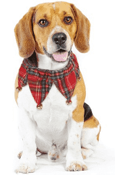

Dogs happen to be the most common household pet. Dog lovers have found the we rate dogs twitter handle to a forum for sharing pictures of dogs and rating them. An analysis of the we rate dog twitter dataset was conducted and it shows a couple of things about users engagement and about the breeds of dogs users love most.

The following insights were drawn from the analysis of the datasets. The first two insight has both public for the users of the we rate dogs and internal relevance for the we rate dog organization, the third insight is specifically for the internal use of the we rate dog organization.

#### 1) Users' Device type

- The we rate dogs Twitter handle is user centric; for an audience of dog lovers. As different users use different devices in accessing the webpage it is important to classify the devices users are using to enage with the site, this could be for the purposes of webpage optimization, ad marketing, driving more user conversions and engagement.
- The analysis of the device type results in the bar chart below :

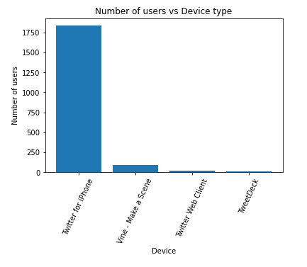

- The chart above shows that more Iphone users enagage more with we rate dogs twitter handle followed by users of the vine and twitter web client and we the least number of users using TweetDeck.

#### 2) The favorite dog breed

- While there are different breeds of dogs being rated on the we rate dog Twitter handle, the chart below shows that the Golden Retriever is the most loved breed of dog among the users of the we rate dogs, followed by the Labrador Retriever, the Pembroke, Chihuanhua and the Samoyed, the french bull dog, Chow, Pug, Cocker Spaniel, Pomeranian and Cardigan in that order. A quick observation shows that the Retrievers both the Golden and the Labrador happen to be loved among people.

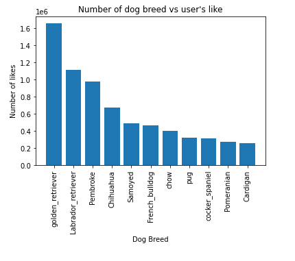

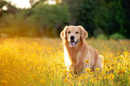

Golden Retriever

#### 3) Accuracy of the three image prediction algorithms

- The analysis of the we rate dog datasets shows that the three prediction alogrithms detects different breeds from the image presented, hence there is a need retrain the classification model to ensure accuracy and consistency.

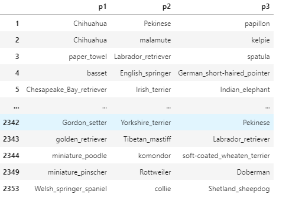